# Group Project

10/04/2020

# Biological Questions

1. What is the diversity of bacteria within the belly button samples?

2. How different/similar are the two populations’ belly button microbiomes?

3. What is the evolutionary relationship between the different species found in one sample (one belly button)?

# Question 1

Libraries.

```r
library(ggplot2)
library(ape)
library(ggtree)
library(vegan)
```

## Setup Sample Information

Import the sample information.

```r
Samples <- read.csv("data/sample_info.csv")
```

## Setup OTU table

Import OTU table.

```r
OTU_table <- read.delim("data/OTU_file.txt", header = T, row.names = "X.OTU.ID")
```

Remove taxonomy column from OTU table.

```r
OTU_data <- OTU_table[, -c(1, ncol(OTU_table))]
```

Calculate the total sequences in the dataset.

```r
x <- rowSums(OTU_data)
sum(x)
```

```
## [1] 24000
```

```r
drop <- rowSums(OTU_data) < 2
sum(drop)  # The number of sequences being removed.
```

```
## [1] 896
```

```r
OTU_red <- OTU_data[!drop, ]
```

Transpose the table so that the species are across the top and the samples are along the side.

```r
OTU_red[1:3, 1:3]  # Preview the layout of the original data.frame.
```

```
##      B1234 B1235 B1236
## 2151     0     0     0
## 347      0     0     0
## 1192     0     0     0
```

```r
OTUs <- as.data.frame(t(OTU_red))
OTUs[1:3, 1:3]  # Ensure transpose worked.
```

```
##       2151 347 1192
## B1234    0   0    0
## B1235    0   0    0
## B1236    0   0    0
```

## Analysis

### Binary Method

Change OTUs data.frame into binary data by changing the read counts in each sequence to 1 or 0.

```r
OTU_bin <- OTUs
OTU_bin[OTU_bin > 0] <- 1
```

Calculate the pairwise distance of the binary matrix.

```r
OTU_bin_dist <- dist(OTU_bin, method = "binary")
```

Build the binary neighbour-joining tree, annotate it using the sample information, and output it as a pdf.

```r
OTU_bin_tree <- nj(OTU_bin_dist)

pdf(width = 16, height = 20, "Binary_Tree.pdf")
ggtree(OTU_bin_tree, layout = "rectangular") %<+% Samples +
  geom_tiplab(aes(colour = collection)) +
  theme(legend.position = "right")
dev.off()
```

### Euclidean Method

Calculate the euclidean distance.

```r
OTU_euc_dist <- dist(OTUs, method = "euclidean")
```

Build the euclidean neighbour-joining tree, annotate it using the sample information, and output it as a pdf.

```r
OTU_euc_tree <- nj(OTU_euc_dist)

pdf(width = 16, height = 20, "Euclidean_Tree.pdf")
ggtree(OTU_euc_tree, layout = "rectangular") %<+% Samples +
  geom_tiplab(aes(colour = collection)) +
  theme(legend.position = "right")
dev.off()
```

### Bray-Curtis Dissimilarity Method

Calculate the Bray-Curtis dissimilarity.

```r
OTU_bc_dist <- vegdist(OTUs, method = "bray", binary = T)
```

Build the Bray-Curtis dissimilarity neighbour-joining tree, annotate it using the sample information, and output it as a pdf.

```r
OTU_bc_tree <- nj(OTU_bc_dist)

pdf(width = 16, height = 20, "Bray_Curtis_Tree.pdf")
ggtree(OTU_bc_tree, layout = "rectangular") %<+% Samples +
  geom_tiplab(aes(colour = collection)) +
  theme(legend.position = "right")
dev.off()
```

### Non-Metric Multidimensional Scaling (NMDS)

Perform the model.

```r
set.seed(13)
NMDSdat <- metaMDS(OTU_bc_dist, k = 2, trymax = 100)
```

[output not shown]

Create data for plotting.

```r
PDat <- data.frame(NMDS1 = NMDSdat$points[ , 1],
                   NMDS2 = NMDSdat$points[ , 2],
                   sample = row.names(OTUs))
```

```r
PDat <- merge(PDat, Samples, by = "sample", all.x = T, all.y = F)
```

Plot the NMDS.

```r
qplot(x = NMDS1, NMDS2, colour = collection, alpha = I(0.6), data = PDat) +
  theme_bw()
```

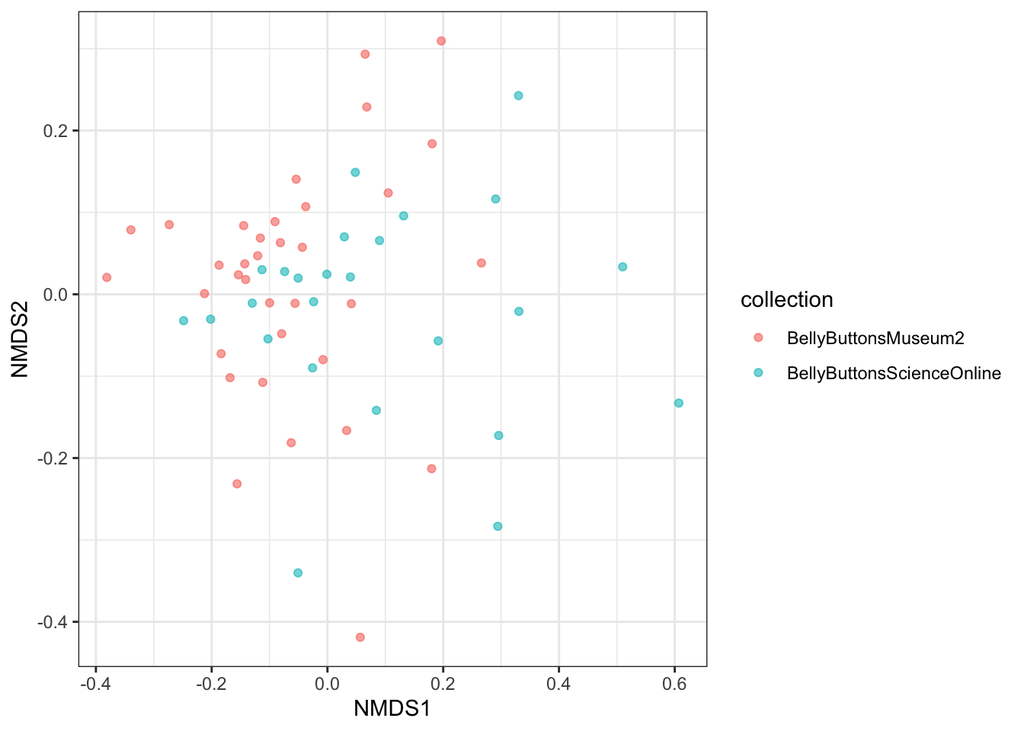